# Patterns in Bay Wheels Dataset

### by RAJAT PRASAD

## Investigation Overview

This is the second part of project. In this part I focus on the patters which I find in exploration part.

The main area of focus:

1. Proportion of rides done by each user type.
2. Distribution of ride duration and distance.
3. Average ride duration and distance for each user type.
4. Rides by days of week and month for each user type.
5. Peak hours of rides.
6. Hourly and Weekly Rides for Each User Type.

## Dataset Overview

For original dataset and list of all variables avilable in dataset https://www.lyft.com/bikes/bay-wheels/system-data.

## Proportion of Rides Done by Each User Type

About 82.23% of rides are done by subscriber of Bay Wheels bicycle sharing system and about 17.77% of rides are done by non subscriber.

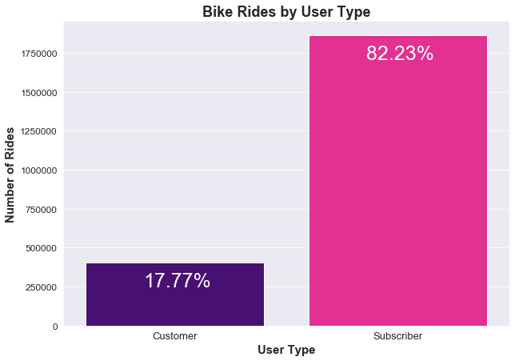

```python
# setting background style
sns.set_style('darkgrid')

# setting figure size
plt.figure(figsize=(10, 7))

ax = plt.subplot(111)

# plotting bar chart
ax = sns.countplot(data = bay_wheels, x='user_type', palette=['indigo','deeppink'], ax=ax)

# total number of rows
total = bay_wheels.shape[0]


for i in ax.patches:
    # get_x for left or right and get_height for up or down
    ax.text(i.get_x()+.26, i.get_height()-150000, \
            str(round((i.get_height()/total)*100, 2))+'%', fontsize=25, color='white')


plt.xlabel('User Type', fontsize=15, weight='bold')
plt.ylabel('Number of Rides', fontsize=15, weight='bold')
plt.xticks(fontsize=13)
plt.yticks(fontsize=12)
plt.title('Bike Rides by User Type', fontsize=18, weight='bold');
```

## Distribution of Ride Duration and Distance

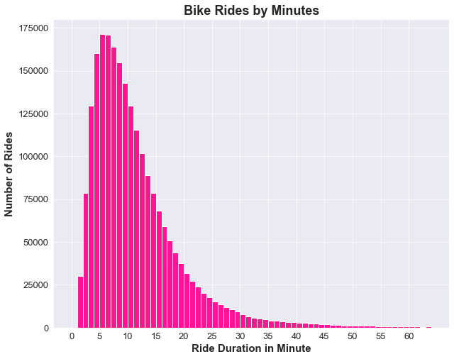

```python
plt.figure(figsize=(10,8))

# plotting histogram of ride duration
plt.hist(data=bay_wheels, x='duration_min',bins=np.arange(0, 65), color='deeppink')

plt.xlabel('Ride Duration in Minute', fontsize=15, weight='bold')
plt.ylabel('Number of Rides', fontsize=15, weight='bold')
plt.xticks(np.arange(0, 65, 5), fontsize=13)
plt.yticks(fontsize=13)
plt.title('Bike Rides by Minutes', fontsize=18, weight='bold');
```

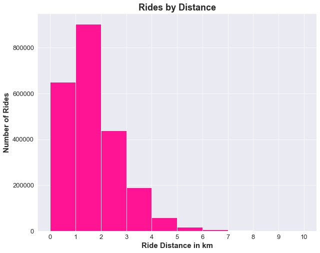

```python
plt.figure(figsize=(10,8))

plt.hist(data=bay_wheels, x='distance_km',bins=np.arange(0, 11), color='deeppink')

plt.xlabel('Ride Distance in km', fontsize=15, weight='bold')
plt.ylabel('Number of Rides', fontsize=15, weight='bold')
plt.xticks(np.arange(0, 11, 1), fontsize=13)
plt.yticks(fontsize=13)
plt.title('Rides by Distance', fontsize=18, weight='bold');
```

## Peak Hour of Rides

Rides are at peak in morning at 8 and in evening at 5. This mainly due working hours.

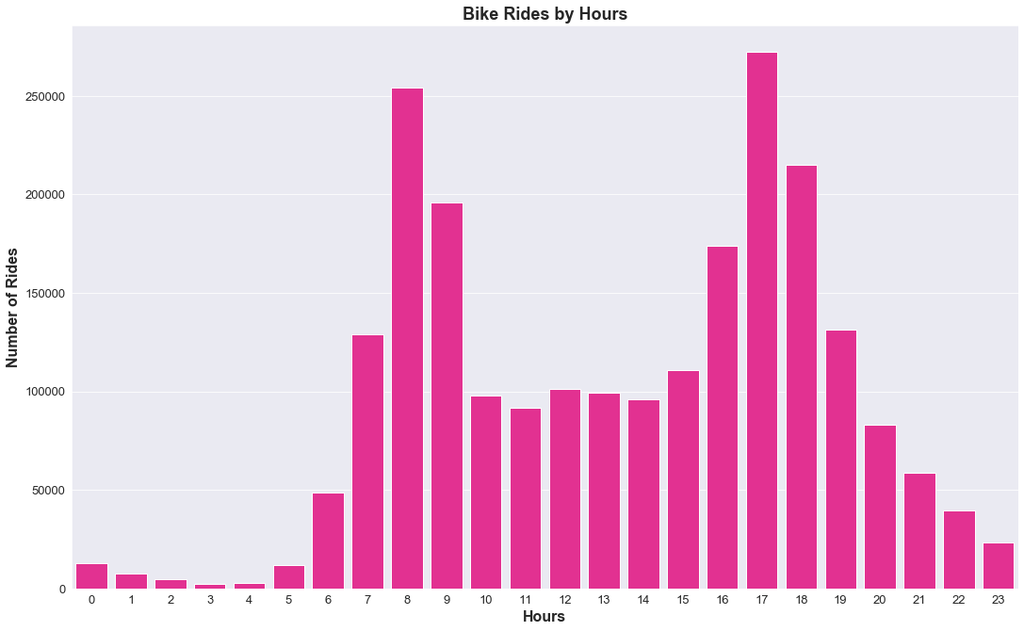

```python
plt.figure(figsize=(18,11))

ax = plt.subplot(111)

ax = sns.countplot(data=bay_wheels, x='start_hour', color='deeppink', ax=ax)

plt.ylabel('Number of Rides', fontsize=16, weight='bold')
plt.xlabel('Hours', fontsize=16, weight='bold')
plt.xticks(fontsize=13)
plt.yticks(fontsize=13)
plt.title('Bike Rides by Hours', fontsize=18, weight='bold');
```

## Average Ride Duration and Distance for Each User Type

Average ride duration and distance for customer is more than subscriber.

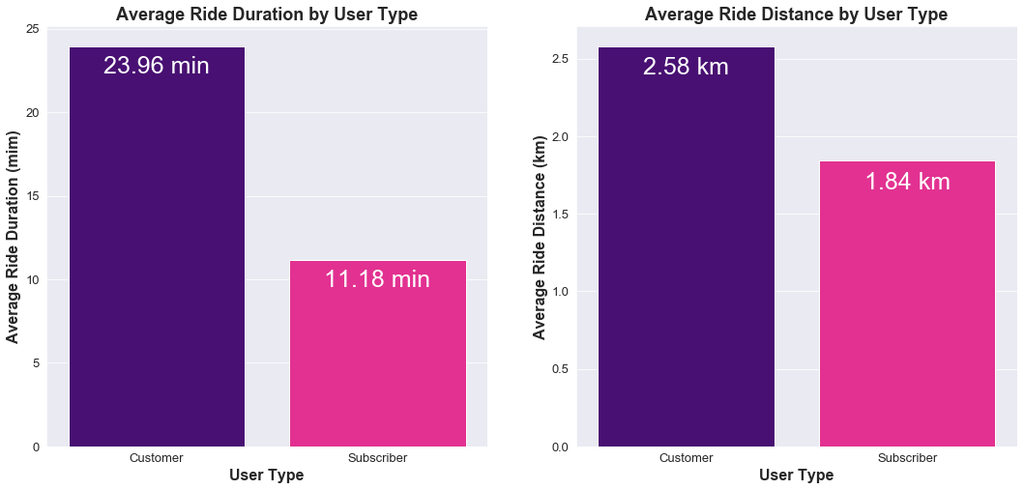

```python
plt.figure(figsize = [18,8])
avg_ride = bay_wheels.groupby('user_type').mean().reset_index()

plt.subplot(1,2,1)

ax = sns.barplot(x='user_type', y='duration_min', data=avg_ride, palette=['indigo','deeppink'])

for index, row in avg_ride.iterrows():
    ax.text(row.name,row.duration_min-1.6, str(round(row.duration_min,2))+' min', color='white', ha="center", fontsize=25)

plt.ylabel('Average Ride Duration (mim)', fontsize=16, weight='bold')
plt.xlabel('User Type', fontsize=16, weight='bold')
plt.xticks(fontsize=13)
plt.yticks(fontsize=13)
plt.title('Average Ride Duration by User Type', fontsize=18, weight='bold')


plt.subplot(1,2,2)

ax = sns.barplot(x='user_type', y='distance_km', data=avg_ride, palette=['indigo','deeppink'])

for index, row in avg_ride.iterrows():
    ax.text(row.name,row.distance_km-.18, str(round(row.distance_km,2))+' km', color='white', ha="center", fontsize=25)

plt.ylabel('Average Ride Distance (km)', fontsize=16, weight='bold')
plt.xlabel('User Type', fontsize=16, weight='bold')
plt.xticks(fontsize=13)
plt.yticks(fontsize=13)
plt.title('Average Ride Distance by User Type', fontsize=18, weight='bold');
```

## Rides by Days of Week and Month for Each User Type

- Rides done by customer is nearly equal to each days of weeks but subscriber rides more on regular days than weekends.
- Subscriber ride more in March and April and very less in July.
- Customer rides less wholes year compare to subscriber.

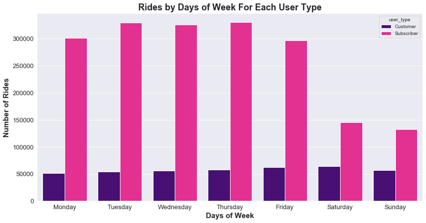

```python
plt.figure(figsize=(14,7))
ax = plt.subplot(111)

ax = sns.countplot(data=bay_wheels, x='start_day', palette=['indigo','deeppink'], hue='user_type', ax=ax)

plt.xlabel('Days of Week', fontsize=15, weight='bold')
plt.ylabel('Number of Rides', fontsize=15, weight='bold')
plt.xticks(fontsize=13)
plt.yticks(fontsize=13)
plt.title('Rides by Days of Week For Each User Type', fontsize=18, weight='bold');
```

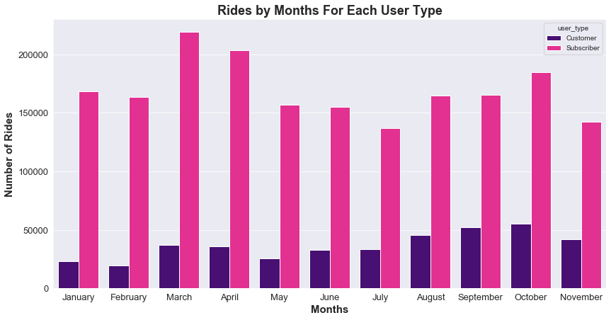

```python
plt.figure(figsize=(14,7))
ax = plt.subplot(111)

ax = sns.countplot(data=bay_wheels, x='start_month', palette=['indigo','deeppink'], hue='user_type', ax=ax)

plt.xlabel('Months', fontsize=15, weight='bold')
plt.ylabel('Number of Rides', fontsize=15, weight='bold')
plt.xticks(fontsize=13)
plt.yticks(fontsize=13)
plt.title('Rides by Months For Each User Type', fontsize=18, weight='bold');
```

## Hourly and Weekly Rides for Each User Type

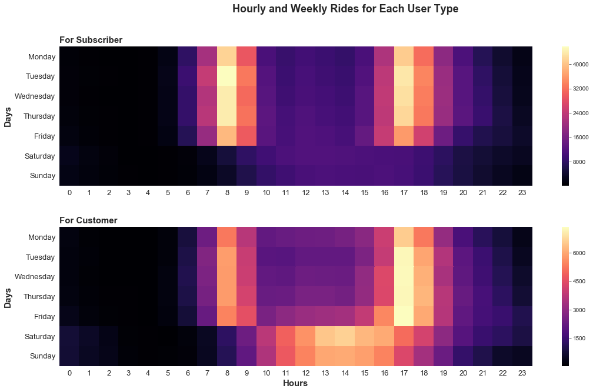

```python
plt.figure(figsize = [18, 10])

plt.subplot(2, 1, 1)

sub_count = bay_wheels_sub.groupby(['start_day', 'start_hour']).size()
sub_count = sub_count.reset_index(name='count')
sub_count = sub_count.pivot(index='start_day', columns='start_hour', values='count')
sns.heatmap(sub_count, cmap='magma')
plt.title('For Subscriber', loc='left', fontsize=15, weight='bold')
plt.xticks(fontsize=13)
plt.yticks(fontsize=13)
plt.xlabel('', fontsize=15, weight='bold')
plt.ylabel('Days', fontsize=15, weight='bold')

plt.subplot(2, 1, 2)

cus_count = bay_wheels_cus.groupby(['start_day', 'start_hour']).size()
cus_count = cus_count.reset_index(name='count')
cus_count = cus_count.pivot(index='start_day', columns='start_hour', values='count')
sns.heatmap(cus_count, cmap='magma')
plt.title('For Customer', loc='left', fontsize=15, weight='bold')
plt.xticks(fontsize=13)
plt.yticks(fontsize=13)
plt.xlabel('Hours', fontsize=15, weight='bold')
plt.ylabel('Days', fontsize=15, weight='bold')

plt.subplots_adjust(hspace = 0.3)
plt.suptitle('Hourly and Weekly Rides for Each User Type', fontsize=18, weight='bold');
```